Bennett Widyolar  
ES 207 - HW #6  
4/1/2016

# Homework Assignment 6

## Objective

The objective of this study is to validate independent hydrogeomorphic type labels assigned to a select set of meadows in the Sierra Nevada. Validation will be performed by cluster analysis across several important variables.

## Methods

This study will be carried out by analyzing data from selected meadow sites across the Sierra Nevada. Cluster computations, performed in R, (hierarchical clustering and k-means clustering) will be used along with principal component analylsis for each cluster for a set of measured data determined to be important.

## Data

Meadow data comes from the following source: Fryjoff-Hung & Viers, 2012. Sierra Nevada Multi-Source Meadow Polygons Compilation (v 1.0), Center for Watershed Sciences, UC Davis. December 2012. http://meadows.ucdavis.edu/

DEM data for California is also used, over which meadow location and cluster attributes are plotted.

## Code

The code for this project is as follows:

```r
#CLEAR VARIABLES
rm(list=ls())
frame()

#install.packages("foreign")
library(foreign)
#install.packages("rgdal")
library(rgdal)
#install.packages("raster")
library(raster)

#LOAD DBF FILE
meadows <- read.dbf('Sierra_Nevada_MultiSource_Meadow_Polygons_Compilation_v1.dbf')

#SUBSET TO RECORDS HAVING HGM VALUES
meadows <- subset(meadows, !is.na(HGM_TYPE))

#FORMATE DATA FRAME COLUMNS
meadows$area.sqkm = meadows[,"Shape_Area"]/1000000 # m^2 to km^2
meadows$catch.sqkm = meadows[,"CATCHMENT_"]/1000000# m^2 to km^2
meadows$elev_m = meadows[,"ELEV_MEAN"]
meadows$elev_r = meadows[,"ELEV_RANGE"]
meadows$lat_dd = meadows[,"LAT_DD"]
meadows$lon_dd = meadows[,"LONG_DD"]
meadows$slope.pct = meadows[,"FLOW_SLOPE"]
meadows$edge.comp = meadows[,"EDGE_COMPL"]
meadows$clay = meadows[,"ClayTot_r"]
meadows$soil.kf = meadows[,"Kf"]

#NOTE RELEVANT COLUMNS
rel_cols = c("area.sqkm", "catch.sqkm", "elev_m", "elev_r", "lat_dd", "lon_dd", "slope.pct", "edge.comp", "clay", "soil.kf")

pairs(~area.sqkm + catch.sqkm + elev_m + elev_r + lat_dd + lon_dd + slope.pct + edge.comp + clay + soil.kf,data=meadows)
#pairs(meadows[rel_cols],data=meadows) -> produces 50+ warnings!


#dist using euclidean
meadows.dist <- dist(x = meadows[,rel_cols],method = "euclidean")
#hclust using ward.D
meadows.hc <- hclust(meadows.dist,method="ward.D")

####################################### HIERARCHICAL CLUSTERING

#PLOT WITH RECTANGLES AROUND CLUSTERS
plot(meadows.hc)
rect.hclust(meadows.hc, k=6)

#STORE CLUSTER GROUP NUMBER IN DATA FRAME
meadows$hc6 <- cutree(meadows.hc, k=6)

######################################### K MEANS CLUSTERING

#K MEANS CLUSTERING
meadows.km6 <- kmeans(meadows[,rel_cols],centers =6)
#STORE GROUP #
meadows$km6 <- meadows.km6$cluster

#COMPARE CLUSTERING METHODS
table(meadows$hc6, meadows$km6)

gdal_grid = readGDAL("DEM.tif")
DEM = raster(gdal_grid) #use data as a projected raster
plot(DEM, col=gray.colors(10, start=0.9, end=0.3),main="Hierarchical Cluster Locations")

#PLOT HC CLUSTERS
codeColors = c("red","blue","green","black","orange","yellow")
points(meadows$lon_dd,meadows$lat_dd,col=codeColors[meadows$hc6],pch=20)
#DOUBLE CHECK BELOW
#clusters <- aggregate(cbind(lat_dd,lon_dd) ~ hc6, data=meadows, mean)
#points(clusters$lon_dd,clusters$lat_dd,col=codeColors,pch=15)

#PLOT KMEANS CLUSTERS
plot(DEM, col=gray.colors(10, start=0.9, end=0.3),main="K-Means Cluster Locations")
points(meadows$lon_dd,meadows$lat_dd,col=codeColors[meadows$km6],pch=20)
#DOUBLE CHECK BELOW
#clusters <- aggregate(cbind(lat_dd,lon_dd) ~ km6, data=meadows, mean)
#points(clusters$lon_dd,clusters$lat_dd,col=codeColors,pch=15)


#########################       PRINCIPAL COMPONENT ANALYSIS - PCA

meadows.pca <- prcomp(x = meadows[,rel_cols], scale=TRUE, retx = TRUE, center = TRUE, scores=TRUE)
print("Principal Component Analylsis")
print(summary(meadows.pca))

plot(meadows.pca,type="lines")

print(meadows.pca$rotation)

biplot(meadows.pca, choices=1:2, cex=0.5, xlim=c(-0.1,0.2), ylim=c(-0.1,0.2))
biplot(meadows.pca, choices=2:3, cex=0.5, xlim=c(-0.1,0.3), ylim=c(-0.12,0.2))
biplot(meadows.pca, choices=3:4, cex=0.5, xlim=c(-0.12,0.25), ylim=c(-0.12,0.2))
biplot(meadows.pca, choices=4:5, cex=0.5, xlim=c(-0.2,0.25), ylim=c(-0.12,0.35))

pairs(meadows.pca$x[,1:5],col=meadows$km6)
pairs(meadows.pca$x[,1:5],col=meadows$hc6)

#CONTINGENCY ANALYSIS
print(table(meadows$HGM_TYPE,meadows$km6))
print(table(meadows$HGM_TYPE,meadows$hc6))

chisq.test(meadows$HGM_TYPE,meadows$km6)
chisq.test(meadows$HGM_TYPE,meadows$hc6)

print(table(meadows$DOM_ROCKTY,meadows$km6))
print(table(meadows$VEG_MAJORI,meadows$km6))

chisq.test(meadows$DOM_ROCKTY,meadows$km6)
chisq.test(meadows$VEG_MAJORI,meadows$km6)

#SUMMARIZE DATA BY NATIONAL FOREST AND CLUSTER TYPE
ownership <- aggregate(AREA_ACRE ~ km6+OWNERSHIP, data=meadows, sum)
```

## Results

Note: “!is.na()” means -> IS NOT NULL

[output not shown]

[output not shown]

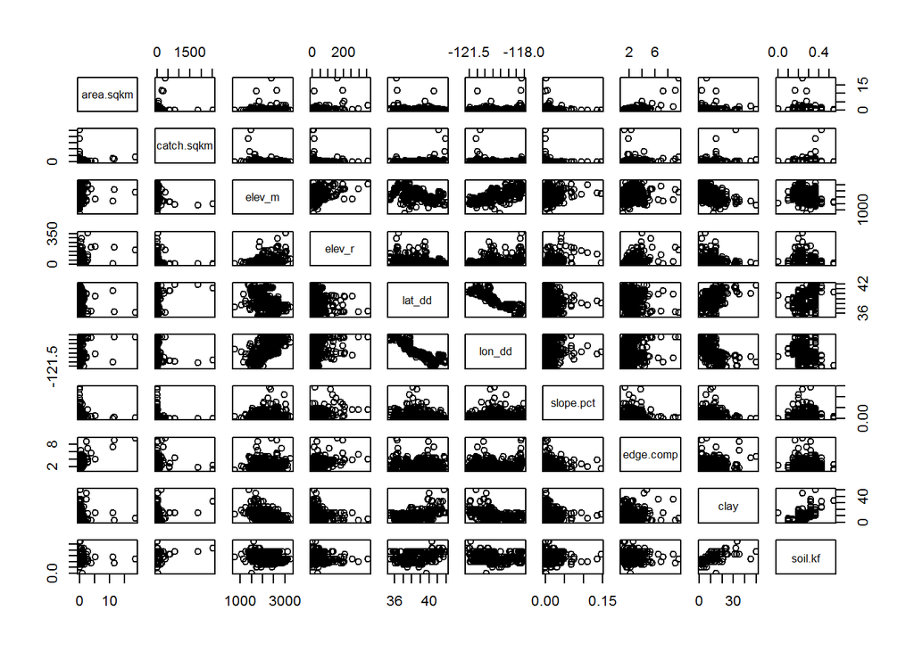

Hierarchical clustering is performed for 6 clusters.

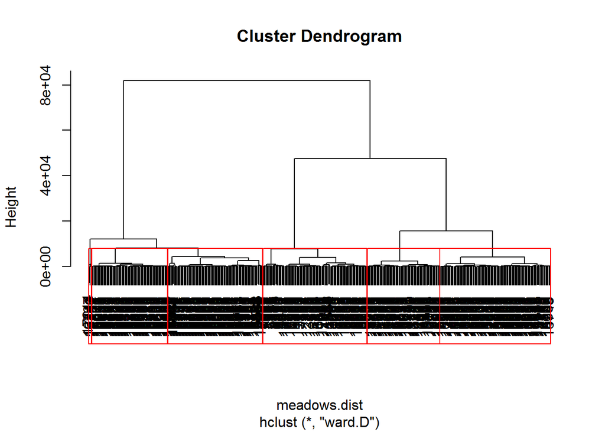

```
## DEM.tif has GDAL driver GTiff
## and has 1137 rows and 1233 columns
```

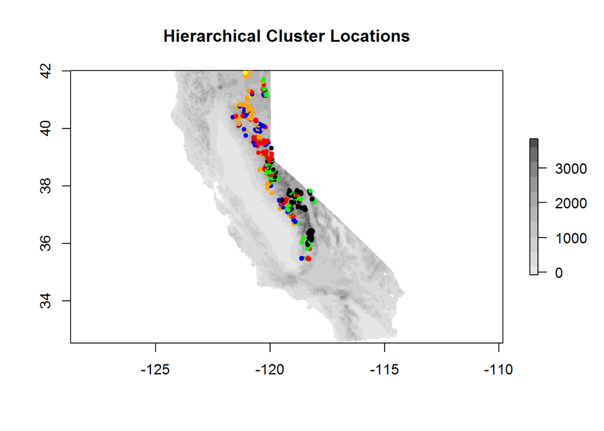

As well as K-means clustering with 6 groups.

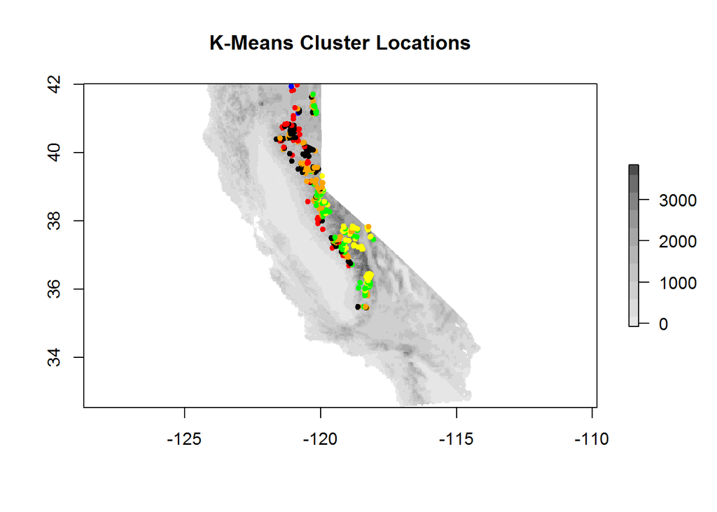

```
##
##      1  2  3  4  5  6
##   1  0  0  0 12 93  0
##   2  0  0  0 72  0  0
##   3  0  0 59  0 10  0
##   4  0  0 31  0  0 68
##   5 63  0  0 27  0  0
##   6  0  3  0  0  0  0
```

Principal Component Analysis (PCA) is performed on the meadows data.

```
## [1] "Principal Component Analylsis"
```

```
## Importance of components:
##                           PC1   PC2    PC3    PC4     PC5     PC6     PC7
## Standard deviation     1.8626 1.368 1.1084 1.0303 0.93022 0.68970 0.62348
## Proportion of Variance 0.3469 0.187 0.1229 0.1062 0.08653 0.04757 0.03887
## Cumulative Proportion  0.3469 0.534 0.6568 0.7630 0.84950 0.89707 0.93594
##                            PC8     PC9    PC10
## Standard deviation     0.53982 0.53098 0.25931
## Proportion of Variance 0.02914 0.02819 0.00672
## Cumulative Proportion  0.96508 0.99328 1.00000
```

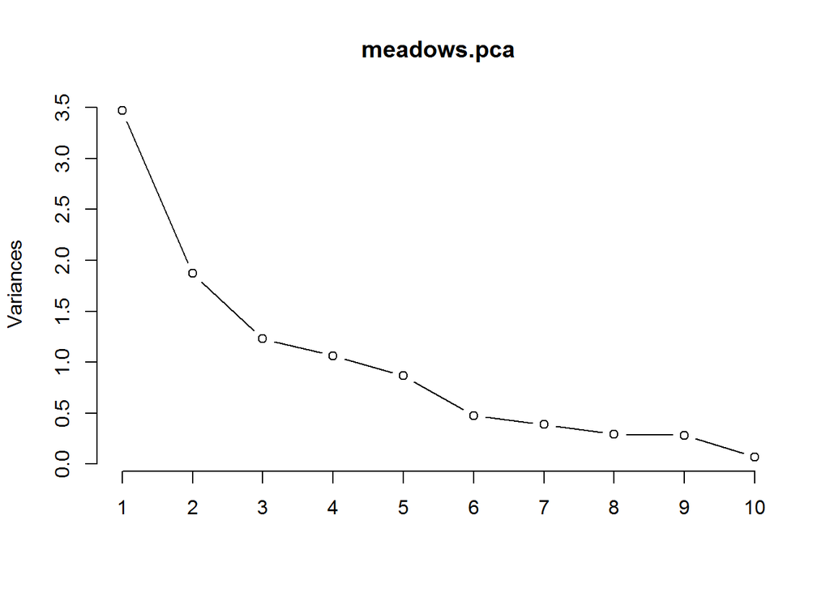

85% of the variance is explained within the first 5 Principal Component Axes. Contributions to each PCA axis by recorded variables are listed below followed by bi-plots and scatter plot matrices.

```r
print(meadows.pca$rotation)
```

```
##                   PC1          PC2         PC3          PC4         PC5
## area.sqkm  -0.1462876  0.554159722 -0.31168141  0.006739313 -0.11940625
## catch.sqkm  0.1289898  0.234746951 -0.05051764 -0.440247563  0.85288162
## elev_m     -0.4282282 -0.068885333  0.11763352 -0.130289127  0.01019772
## elev_r     -0.3269176  0.368857465  0.26743625  0.265512438  0.11165711
## lat_dd      0.4419842  0.125131661 -0.07763722  0.342372974  0.11382757
## lon_dd     -0.4623744 -0.082709361  0.07771838 -0.413325197 -0.08167852
## slope.pct  -0.2029250  0.003768749  0.59098183  0.467964316  0.30697839
## edge.comp  -0.1580674  0.604954813 -0.16185719  0.061295039 -0.15050199
## clay        0.3770195  0.254952226  0.36210215 -0.124183140 -0.19742971
## soil.kf     0.2329363  0.208604685  0.54433440 -0.438678067 -0.26508608
##                     PC6         PC7         PC8          PC9         PC10
## area.sqkm  -0.354512796  0.58937742 -0.18708568 -0.227863241  0.009518696
## catch.sqkm  0.002694082 -0.02418607  0.04156748 -0.005568175 -0.046123814
## elev_m      0.670616837  0.46281889  0.23312179 -0.109766969 -0.225023700
## elev_r      0.243243504 -0.40270320 -0.54906926 -0.280240829 -0.035121036
## lat_dd      0.455508457  0.23927745 -0.08212863  0.080459425  0.612232006
## lon_dd     -0.111527187 -0.10100697  0.06277639 -0.088017314  0.749327148
## slope.pct  -0.356495961  0.24965721  0.26777011  0.168070208  0.083395896
## edge.comp   0.130318470 -0.31719902  0.47670360  0.459956659 -0.005840521
## clay        0.002913792 -0.10417633  0.42817052 -0.642712041  0.008232692
## soil.kf     0.037577175  0.18554067 -0.33835653  0.436298489 -0.050367313
```

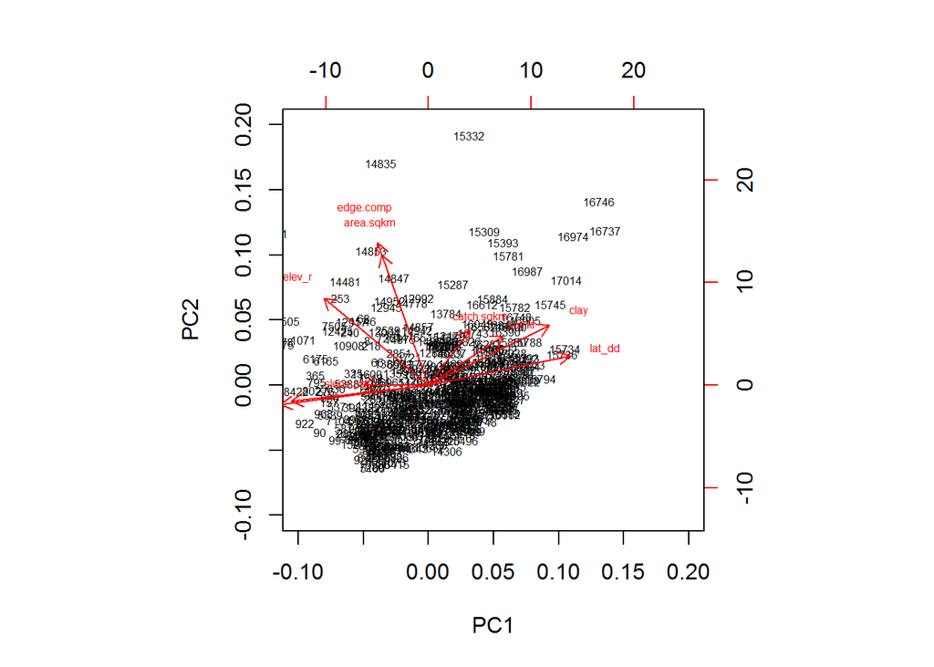

```r
biplot(meadows.pca, choices=1:2, cex=0.5, xlim=c(-0.1,0.2), ylim=c(-0.1,0.2))
```

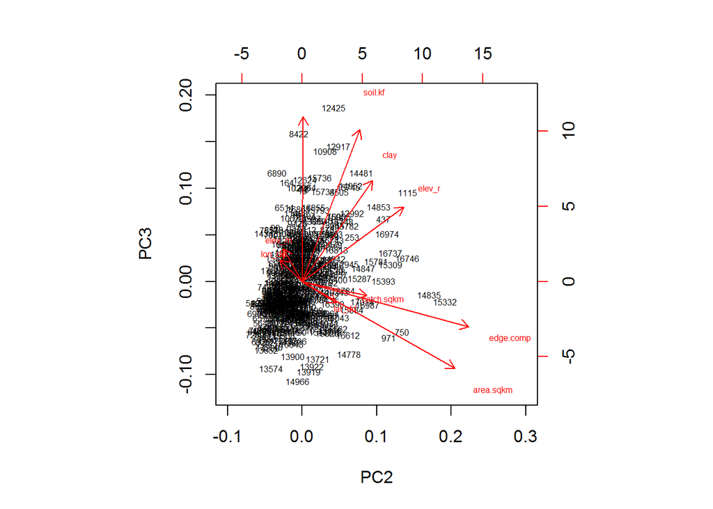

```r
biplot(meadows.pca, choices=2:3, cex=0.5, xlim=c(-0.1,0.3), ylim=c(-0.12,0.2))
```

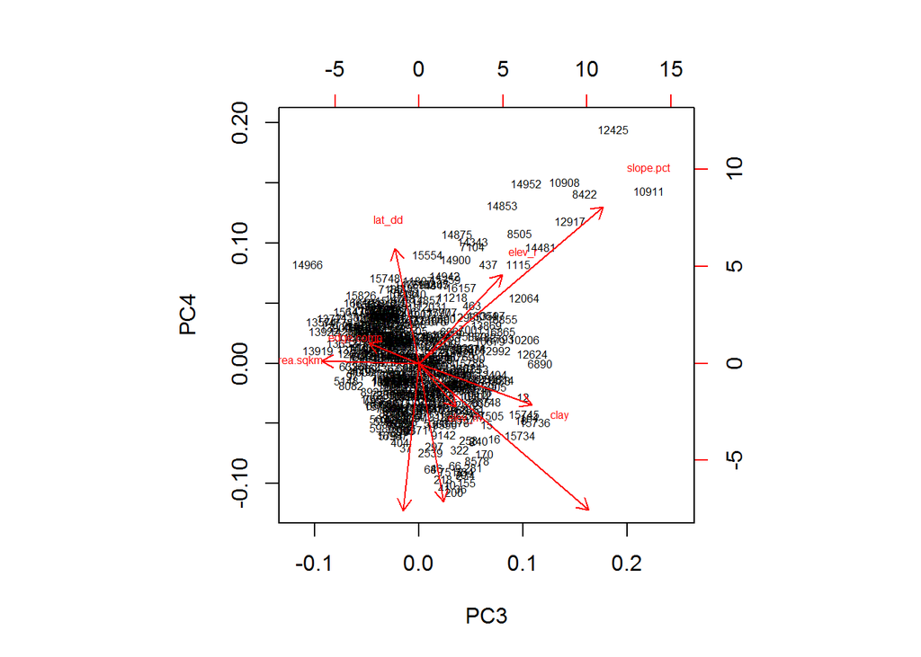

```r
biplot(meadows.pca, choices=3:4, cex=0.5, xlim=c(-0.12,0.25), ylim=c(-0.12,0.2))
```

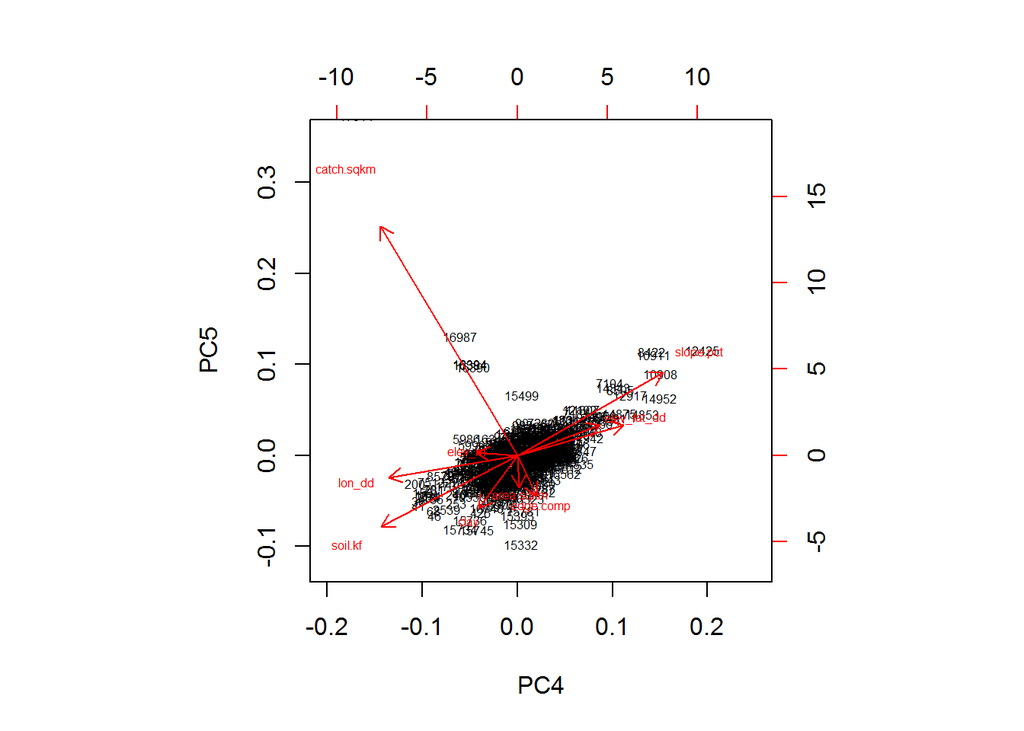

```r
biplot(meadows.pca, choices=4:5, cex=0.5, xlim=c(-0.2,0.25), ylim=c(-0.12,0.35))
```

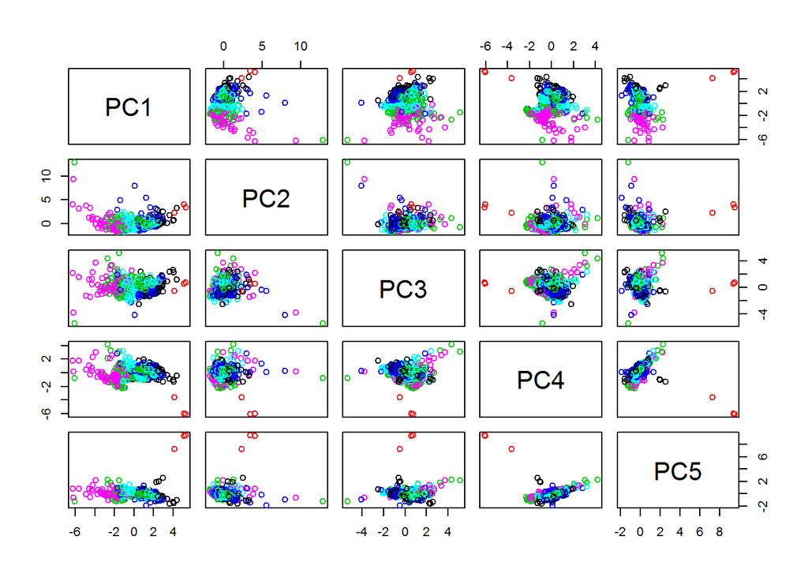

```r
pairs(meadows.pca$x[,1:5],col=meadows$km6)
```

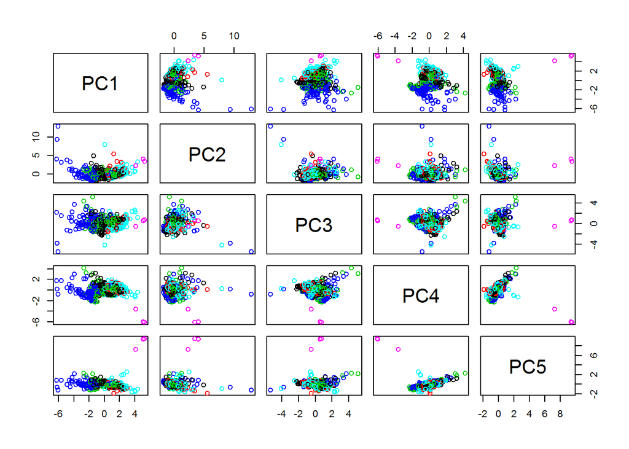

```r
pairs(meadows.pca$x[,1:5],col=meadows$hc6)
```

A contingency analysis is performed to compare the calculated cluster groupings with the HGM Type determined by the USFS. Tables for the HGM Type along with clusters 1-6 for the K-means and Hierarchical clustering are presented below.

```
##
##                               1  2  3  4  5  6
##   Annual grassland            1  0  0  0  0  0
##   Basin peatland              0  0  2  1  0  0
##   Depressional perennial      3  0  0 10  6  0
##   Depressional seasonal       0  0  0  0  1  0
##   Discharge slope             7  0  6  6  5  0
##   Discharge slope peatland    0  0  1  4  5  0
##   Dry                         1  0  1  2  1  3
##   Lacustrine fringe           5  0  2  1  2  0
##   Riparian high gradient      2  0  3  0  3  2
##   Riparian low gradient      19  1 31 62 34 34
##   Riparian middle gradient   11  2 20 12 14 13
##   Subsurface high gradient    1  0  2  3  2  5
##   Subsurface low gradient     7  0 14  8 17  5
##   Subsurface middle gradient  6  0  8  2 13  6
```

```
##
##                               1  2  3  4  5  6
##   Annual grassland            0  0  0  0  1  0
##   Basin peatland              0  1  1  1  0  0
##   Depressional perennial      7  5  0  0  7  0
##   Depressional seasonal       1  0  0  0  0  0
##   Discharge slope             5  6  3  3  7  0
##   Discharge slope peatland    4  3  2  0  1  0
##   Dry                         1  2  1  3  1  0
##   Lacustrine fringe           1  1  2  1  5  0
##   Riparian high gradient      3  0  3  2  2  0
##   Riparian low gradient      40 40 22 45 33  1
##   Riparian middle gradient   15  7 17 18 13  2
##   Subsurface high gradient    2  1  0  7  3  0
##   Subsurface low gradient    14  4 12 10 11  0
##   Subsurface middle gradient 12  2  6  9  6  0
```

The Pearson’s Chi-Squared test shows a high dependency of k-means cluster group to HGM Type.

```
##
##  Pearson's Chi-squared test
##
## data:  meadows$HGM_TYPE and meadows$km6
## X-squared = 102.36, df = 65, p-value = 0.002142
```

```
##
##  Pearson's Chi-squared test
##
## data:  meadows$HGM_TYPE and meadows$hc6
## X-squared = 76.711, df = 65, p-value = 0.1518
```

Other variables (Dominant rock type and vegetation of the meadow) are also investigated.

```
##
##                               1  2  3  4  5  6
##   alluvium                    3  0  2 21  8  2
##   andesite                   38  3 26 54 29  4
##   argillite                   1  0  1  2  1  0
##   basalt                      0  0  0  0  0  1
##   chert                       0  0  0  0  0  0
##   conglomerate                0  0  0  0  0  0
##   dolostone (dolomite)        0  0  1  0  0  1
##   dune sand                   0  0  0  0  0  0
##   felsic volcanic rock        0  0  1  0  0  4
##   gabbro                      0  0  0  0  0  0
##   glacial drift               1  0  7  3 14 15
##   granodiorite               14  0 48 31 45 35
##   hornfels                    0  0  0  0  0  0
##   intermediate volcanic rock  0  0  0  0  1  0
##   landslide                   0  0  0  0  0  0
##   limestone                   0  0  0  0  0  0
##   mafic volcanic rock         0  0  0  0  0  0
##   mudstone                    0  0  0  0  0  0
##   peridotite                  1  0  0  0  0  0
##   phyllite                    0  0  0  0  0  0
##   plutonic rock (phaneritic)  0  0  0  0  0  0
##   rhyolite                    0  0  1  0  1  2
##   sandstone                   3  0  0  0  0  0
##   schist                      0  0  1  0  1  1
##   slate                       0  0  0  0  2  0
##   tephrite (basanite)         0  0  2  0  1  3
##   water                       2  0  0  0  0  0
```

```
##
##                          1  2  3  4  5  6
##   Barren-Rock/Sand/Clay  0  0  0  1  1  0
##   Conifer               22  1 38 52 49 33
##   Grassland              0  0  0  0  0  0
##   Hardwood               2  0  3  0  1  3
##   Hardwood-Conifer       0  0  1  0  0  0
##   Open Water             1  0  0  0  0  0
##   Perrennial Ice/Snow    0  0  0  0  0  0
##   Riparian              28  2 46 50 49 22
##   Shrubland             10  0  2  8  3  9
##   Sparse                 0  0  0  0  0  1
```

```
##
##  Pearson's Chi-squared test
##
## data:  meadows$DOM_ROCKTY and meadows$km6
## X-squared = 190.72, df = 75, p-value = 4.84e-12
```

```
##
##  Pearson's Chi-squared test
##
## data:  meadows$VEG_MAJORI and meadows$km6
## X-squared = 44.682, df = 35, p-value = 0.1265
```

K-means cluster type is highly dependent on the dominant rock type found in the area, but not as dependent on dominant vegetation type.

Lastly, the acreage of each national forest that belongs to each k-means cluster group is determined and the result is saved in the excel file - “ownership - formatted.csv” (I could not get a data frame to print in markdown)

## Limitations

See limitations in meta file (SNMMPCv1_Metadata.txt)